# Extracción de los datos

```python
# Librerias para importar mis propias funciones de un directorio
import sys
import importlib
sys.path.append(r"D:\Camposol S.A\Team Analytics - Documentos\General\1. PYTHON")
import funciones as fn # type: ignore
import pyodbc

import pandas as pd
import numpy as np
from datetime import datetime
import seaborn as sns
import matplotlib.pyplot as plt

import warnings
# Suprimir todos los warnings
warnings.filterwarnings("ignore")
```

```python
importlib.reload(fn)
```

```
<module 'funciones' from 'D:\\Camposol S.A\\Team Analytics - Documentos\\General\\1. PYTHON\\funciones.py'>
```

```python
campana = 2024
con = fn.conectar_sql()
```

```
Conexión exitosa
```

```python
# AreaCultivable
idAreaCultivable = fn.SQL_SP("SP_AREACULTIVABLE",6, campana)

# Evaluadores
evaluadores = pd.read_sql(con=con, sql="""select UserName as usernameP, idUsuario as idUsuarioP, Nombre as NombreP
from Usuario""")

#Fecha última
FechaUltima = pd.read_sql(con=con, sql="""select max(distinct FechaRegistro)  as Fecha
from TBL_M_MANDARINA where idEvaluacion = 42""")

# Pesos Cosecha
pesos_cosecha = pd.read_sql(con=con, sql= f"""
select f.Fundo,p.Parcela,l.Nombre as Lote, CONVERT(DATE, lr.FechaRegistro) AS FechaRegistro,
		CONVERT(DATE, lr.FechaMovil) AS Fecha,
		lr.Valor1 AS Flor, lr.Valor2 AS Pasada, lr.Valor3 as D1, lr.Valor4 AS Peso, lr.Valor5 AS Color
FROM  LecturaRegistro2 lr
	INNER JOIN Usuario u ON u.idUsuario = lr.idUsuario
	INNER JOIN Lote l on l.idLote = lr.idLote
	INNER JOIN Parcela p on p.id = l.idParcela
	INNER JOIN Fundo f on f.id = p.IdFundo
WHERE idEvaluacion = 42 AND CONVERT(DATE, lr.FechaRegistro) BETWEEN '{FechaUltima['Fecha'].iloc[0]}' and convert(date, GETDATE())""")

pesos_cosecha['D1'] = pesos_cosecha['D1'] /100
pesos_cosecha['Fecha'] = pd.to_datetime(pesos_cosecha['Fecha'], format='%Y-%m-%d')
pesos_cosecha['FechaRegistro'] = pd.to_datetime(pesos_cosecha['FechaRegistro'], format='%Y-%m-%d')
```

```
Conexión exitosa
Datos Obtenidos Con Exito
```

# Procesamiento de los datos

```python
pesos_cosecha.groupby(by=['Fecha','FechaRegistro']).agg(
    n=('FechaRegistro','size')
)
```

| Fecha | FechaRegistro | n |
| --- | --- | --- |
| 2024-08-02 | 2024-08-03 | 200 |
| 2024-08-03 | 2024-08-03 | 2004 |
| 2024-08-05 | 2024-08-05 | 4344 |
| 2024-08-07 | 2024-08-07 | 4081 |

```python
date_str = ['2024-08-05','2024-08-07']
date_obj = pd.to_datetime(date_str)

# Extraemos la data por fechas de interés
eval_pesos_cosecha = pesos_cosecha[(pesos_cosecha['FechaRegistro'].isin(date_obj))].copy().reset_index(drop=True)

# Realizamos unas transformaciones a los datos
eval_pesos_cosecha['Peso'] = eval_pesos_cosecha.apply(lambda row: None if row['Peso']<=1 else row['Peso'] , axis=1)
eval_pesos_cosecha['FechaRegistro'] = eval_pesos_cosecha['Fecha'].copy()
eval_pesos_cosecha['Validacion'] = eval_pesos_cosecha.apply(lambda row: 0 if row['D1'] == 0 else 1, axis=1)
eval_pesos_cosecha['atipicos'] = 0

eval_pesos_cosecha.groupby(['Fecha']).size().reset_index(name='N')
```

|  | Fecha | N |
| --- | --- | --- |
| 0 | 2024-08-05 | 4344 |
| 1 | 2024-08-07 | 4081 |

## EDA

```python
eval_pesos_cosecha.head(4)
```

|  | Fundo | Parcela | Lote | FechaRegistro | Fecha | Flor | Pasada | D1 | Peso | Color | Validacion | atipicos |
| --- | --- | --- | --- | --- | --- | --- | --- | --- | --- | --- | --- | --- |
| 0 | YAKUY MINKA | P901 | L12062 | 2024-08-07 | 2024-08-07 | 1 | 4 | 77.9 | 175 | 5 | 1 | 0 |
| 1 | YAKUY MINKA | P901 | L12062 | 2024-08-07 | 2024-08-07 | 1 | 4 | 70.2 | 139 | 4 | 1 | 0 |
| 2 | YAKUY MINKA | P901 | L12062 | 2024-08-07 | 2024-08-07 | 1 | 4 | 59.0 | 84 | 1 | 1 | 0 |
| 3 | YAKUY MINKA | P901 | L12062 | 2024-08-07 | 2024-08-07 | 1 | 4 | 61.9 | 91 | 1 | 1 | 0 |

Busco una distinción de datos por fecha

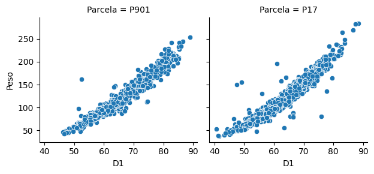

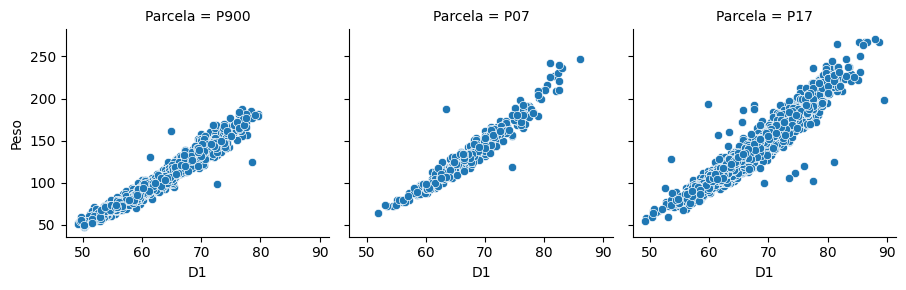

```python
for fecha in eval_pesos_cosecha['Fecha'].unique():
    # Peso vs D1 por fecha
    g = sns.FacetGrid(eval_pesos_cosecha[eval_pesos_cosecha['Fecha']==fecha], col="Parcela", col_wrap=4)
    g.map_dataframe(sns.scatterplot, x="D1", y="Peso")
    g.set_axis_labels("D1", "Peso")
```

Mi objetivo era crear una función que toma el un dataframe y las columnas relacionadas para la detección de outliers, para simplificar el proceso de creación de esta función decidí empezar por una parte del dataframe, me enfocaría en analizar los datos de una fecha en específico

## Detección de outliers por Isolation Forest

Mi primera aproximación al problema fue mediante una aplicación directa del modelo a los datos estandarizados

```python
from sklearn.preprocessing import StandardScaler
from sklearn.ensemble import IsolationForest
import numpy as np
```

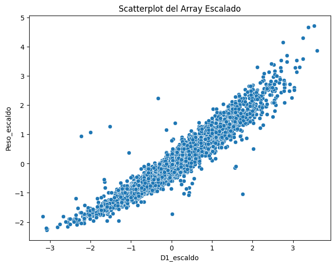

```python
deteccion_IF = eval_pesos_cosecha.copy()

data = deteccion_IF[deteccion_IF['Fecha'] == deteccion_IF['Fecha'].unique()[0]][['D1', 'Peso']]

# Normalizar los datos
scaler = StandardScaler()
data_scalada = scaler.fit_transform(data)

df = pd.DataFrame(data_scalada, columns=['D1_escaldo', 'Peso_escaldo'])

# Crear el scatterplot
plt.figure(figsize=(8, 6))
sns.scatterplot(data=df, x='D1_escaldo', y='Peso_escaldo')
plt.title('Scatterplot del Array Escalado')
plt.show()
```

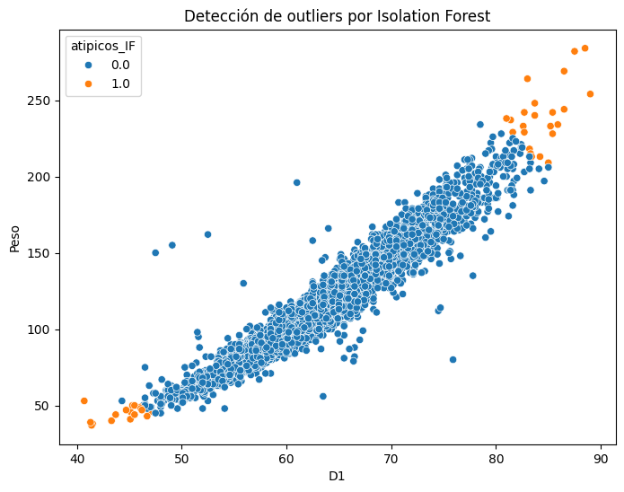

```python
# Aplicar Isolation Forest
isolation_forest = IsolationForest(n_estimators=100, contamination=0.01, random_state=123)
labels = isolation_forest.fit_predict(data_scalada)

# Asignar los resultados al DataFrame original
deteccion_IF.loc[data.index, 'atipicos_IF'] = np.where(labels == -1, 1, 0)

# Crear el scatterplot
plt.figure(figsize=(8, 6))
sns.scatterplot(data=deteccion_IF, x='D1', y='Peso',hue='atipicos_IF')
plt.title('Detección de outliers por Isolation Forest')
plt.show()
```

No convencido con el resultado obtenido, decidí aplicar PCA a los datos después de la normalización, a ver si esto hace alguna diferencia

```python
from sklearn.decomposition import PCA
```

Quería ver el comportamiento entre los datos escalados y los no escalados, por si esto hacía alguna diferencia

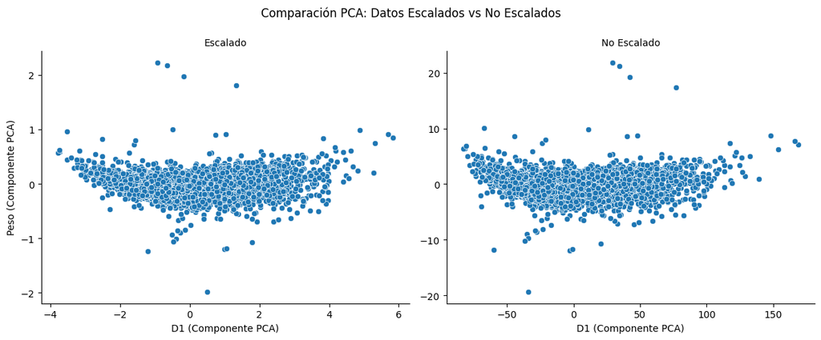

```python
deteccion_IF = eval_pesos_cosecha.copy()

# Dataset con datos escalados
data_escalado = deteccion_IF[deteccion_IF['Fecha'] == deteccion_IF['Fecha'].unique()[0]][['D1', 'Peso']]

scaler = StandardScaler()
data_escalada = scaler.fit_transform(data_escalado)
pca = PCA(n_components=2)
data_pca_escalada = pca.fit_transform(data_escalada)

df_escalado = pd.DataFrame(data_pca_escalada, columns=['D1_escaldo', 'Peso_escaldo'])
df_escalado['Tipo'] = 'Escalado'


# Dataset con datos no escalados
data_no_escalado = deteccion_IF[deteccion_IF['Fecha'] == deteccion_IF['Fecha'].unique()[0]][['D1', 'Peso']]

pca = PCA(n_components=2)
data_pca_no_escalada = pca.fit_transform(data_no_escalado)

df_no_escalado = pd.DataFrame(data_pca_no_escalada, columns=['D1_escaldo', 'Peso_escaldo'])
df_no_escalado['Tipo'] = 'No Escalado'


# Unimos ambos Datasets
df_completo = pd.concat([df_escalado, df_no_escalado], ignore_index=True)

# Graficamos
g = sns.FacetGrid(df_completo, col='Tipo', height=5, aspect=1.2, sharex=False, sharey=False)
g.map_dataframe(sns.scatterplot, x='D1_escaldo', y='Peso_escaldo')

g.set_titles("{col_name}")
g.set_axis_labels("D1 (Componente PCA)", "Peso (Componente PCA)")
plt.subplots_adjust(top=0.85)
g.fig.suptitle('Comparación PCA: Datos Escalados vs No Escalados')
plt.show()
```

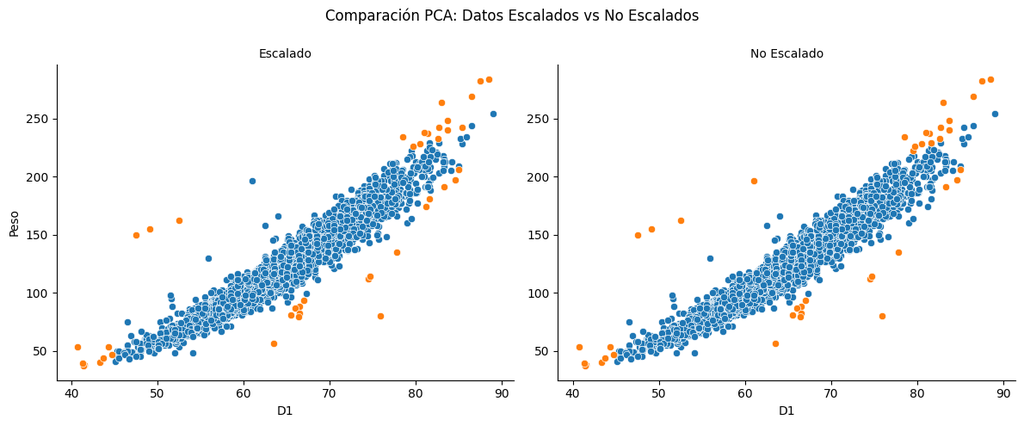

```python
deteccion_IF = eval_pesos_cosecha.copy()

# Dataset con datos escalados
df_escalado = deteccion_IF[deteccion_IF['Fecha'] == deteccion_IF['Fecha'].unique()[0]][['D1', 'Peso']]

scaler = StandardScaler()
data_escalada = scaler.fit_transform(df_escalado)

pca = PCA(n_components=2)
data_pca_escalada = pca.fit_transform(data_escalada)

# Aplicar Isolation Forest
isolation_forest = IsolationForest(n_estimators=100, contamination=0.01, random_state=123)
labels = isolation_forest.fit_predict(data_pca_escalada)

# Asignar los resultados al DataFrame original
df_escalado['atipicos_IF'] = np.where(labels == -1, 1, 0)
df_escalado['Tipo'] = 'Escalado'


# Dataset con datos no escalados
df_no_escalado = deteccion_IF[deteccion_IF['Fecha'] == deteccion_IF['Fecha'].unique()[0]][['D1', 'Peso']]

pca = PCA(n_components=2)
data_pca_no_escalada = pca.fit_transform(df_no_escalado)

# Aplicar Isolation Forest
labels = isolation_forest.fit_predict(data_pca_no_escalada)

# Asignar los resultados al DataFrame original
df_no_escalado['atipicos_IF'] = np.where(labels == -1, 1, 0)
df_no_escalado['Tipo'] = 'No Escalado'


# Unimos ambos Dataframes
df_completo = pd.concat([df_escalado, df_no_escalado], ignore_index=True)

# Graficamos
g = sns.FacetGrid(df_completo, col='Tipo', hue='atipicos_IF', height=5, aspect=1.2, sharex=False, sharey=False)
g.map_dataframe(sns.scatterplot, x='D1', y='Peso')

g.set_titles("{col_name}")
g.set_axis_labels("D1", "Peso")
plt.subplots_adjust(top=0.85)
g.figure.suptitle('Comparación PCA: Datos Escalados vs No Escalados')
plt.show()
```

Me gustó el resultado pero no estaba satisfecho, aún habían datos que no deberían ser considerados como outlier, fue cuando decidí usar el algorimto LOF (Local Outlier Factor)

```python
from sklearn.decomposition import PCA
from sklearn.preprocessing import StandardScaler
from sklearn.neighbors import LocalOutlierFactor
```

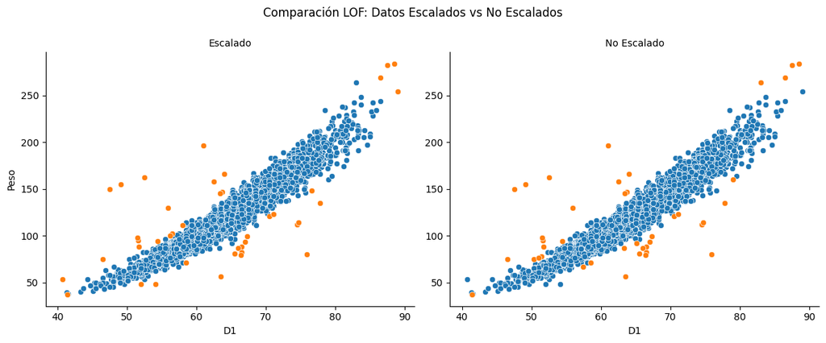

```python
deteccion_LOF = eval_pesos_cosecha.copy()

# Dataset con datos escalados
df_escalado = deteccion_LOF[deteccion_LOF['Fecha'] == deteccion_LOF['Fecha'].unique()[0]][['D1', 'Peso']]

scaler = StandardScaler()
data_escalada = scaler.fit_transform(df_escalado)

pca = PCA(n_components=2)
data_pca_escalada = pca.fit_transform(data_escalada)

# Aplicar Isolation Forest
lof = LocalOutlierFactor(n_neighbors=25, contamination=0.01)
labels = lof.fit_predict(data_pca_escalada)

# Asignar los resultados al DataFrame original
df_escalado['atipicos_IF'] = np.where(labels == -1, 1, 0)
df_escalado['Tipo'] = 'Escalado'


# Dataset con datos no escalados
df_no_escalado = deteccion_LOF[deteccion_LOF['Fecha'] == deteccion_LOF['Fecha'].unique()[0]][['D1', 'Peso']]

pca = PCA(n_components=2)
data_pca_no_escalada = pca.fit_transform(df_no_escalado)

# Aplicar Isolation Forest
labels = lof.fit_predict(data_pca_no_escalada)

# Asignar los resultados al DataFrame original
df_no_escalado['atipicos_IF'] = np.where(labels == -1, 1, 0)
df_no_escalado['Tipo'] = 'No Escalado'


# Unimos ambos Dataframes
df_completo = pd.concat([df_escalado, df_no_escalado], ignore_index=True)

# Graficamos
g = sns.FacetGrid(df_completo, col='Tipo', hue='atipicos_IF', height=5, aspect=1.2, sharex=False, sharey=False)
g.map_dataframe(sns.scatterplot, x='D1', y='Peso')
g.set_titles("{col_name}")
g.set_axis_labels("D1", "Peso")
plt.subplots_adjust(top=0.85)
g.figure.suptitle('Comparación LOF: Datos Escalados vs No Escalados')
plt.show()
```

Con este resultado he quedado más satisfecho pero decidí investigar un poco sobre los hiperparámetros del algoritmo LOF, en cuanto a las métricas me he dado cuenta que la que se usa por defecto no siempre es la mejor, por lo que decidí explorar un poco este hiperparámetro

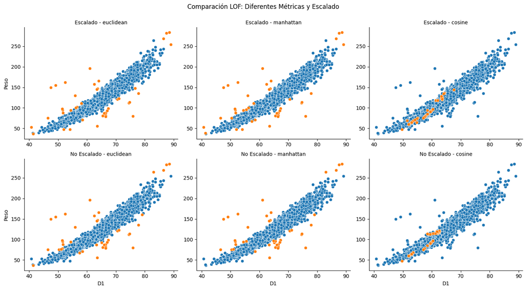

```python
# Lista de métricas que queremos comparar
metricas = ['euclidean', 'manhattan', 'cosine']

# Crear un DataFrame vacío para almacenar los resultados
df_resultados = pd.DataFrame()

# Filtramos los datos por una fecha específica
deteccion_LOF = eval_pesos_cosecha.copy()
df_base = deteccion_LOF[deteccion_LOF['Fecha'] == deteccion_LOF['Fecha'].unique()[0]][['D1', 'Peso']]

# Cree una función para iterar sobre los distintos casos, escalado o no y tipos de métricas
def aplicar_lof(df, escalado, metrica):
    if escalado:
        scaler = StandardScaler()
        data = scaler.fit_transform(df)
        tipo = 'Escalado'
    else:
        data = df.values
        tipo = 'No Escalado'

    # Aplicar PCA
    pca = PCA(n_components=2)
    data_pca = pca.fit_transform(data)

    # Aplicar Local Outlier Factor con la métrica especificada
    lof = LocalOutlierFactor(n_neighbors=25, contamination=0.01, metric=metrica)
    labels = lof.fit_predict(data_pca)

    # Crear DataFrame con los resultados
    df_resultado = df.copy()
    df_resultado['atipicos_IF'] = np.where(labels == -1, 1, 0)
    df_resultado['Tipo'] = tipo
    df_resultado['Metrica'] = metrica

    return df_resultado

# Aplicar LOF para cada combinación de métrica y tipo de dato
for metrica in metricas:
    for escalado in [True, False]:
        resultados = aplicar_lof(df_base, escalado, metrica)
        df_resultados = pd.concat([df_resultados, resultados], ignore_index=True)

# Graficamos
g = sns.FacetGrid(df_resultados, col='Metrica', row='Tipo', hue='atipicos_IF', height=4, aspect=1.2, sharex=False, sharey=False)
g.map_dataframe(sns.scatterplot, x='D1', y='Peso')
g.set_titles("{row_name} - {col_name}")
g.set_axis_labels("D1", "Peso")
plt.subplots_adjust(top=0.9)
g.figure.suptitle('Comparación LOF: Diferentes Métricas y Escalado')
plt.show()
```

Cierro con esta gráfica, la que me permitió escoger el mejor modelo para la tarea en cuestión, creando así la función que deseaba

## Funciones para la detección de outliers

```python
# Detección por medio del algoritmo Isolation Forest
def deteccion_outliers_IF(df, cols, contamination):
    # Verificar que las columnas existen en el DataFrame
    for col in cols:
        if col not in df.columns:
            raise ValueError(f"La columna {col} no existe en el DataFrame")

    # Seleccionar las columnas indicadas
    data = df[cols]

    # Aplicar PCA
    pca = PCA(n_components=2)
    data_pca = pca.fit_transform(data)

    # Aplicar Isolation Forest
    isolation_forest = IsolationForest(n_estimators=100, contamination=contamination, random_state=123)
    labels = isolation_forest.fit_predict(data_pca)

    # Verificar si la columna 'atipicos' ya existe
    if 'atipicos' in df.columns:
        # Solo marcar como outliers las filas que no han sido previamente marcadas
        df['atipicos'] = np.where((labels == -1) & (df['atipicos'] != 1), 1, df['atipicos'])
    else:
        # Añadir columna de outliers al DataFrame original
        df['atipicos'] = np.where(labels == -1, 1, 0)

    return df

# Detección por medio del algoritmo LOF
def detteccion_ouliers_LOF(df, cols, contaminacion = 0.1, n_neighbors = 20, reset = False, metric='manhattan'):
    # Verificar si las columnas existen en el DataFrame
    if not all(col in df.columns for col in cols):
        raise ValueError(f"Una o más columnas de {cols} no existen en el DataFrame")

    # Seleccionar las columnas indicadas
    data = df[cols]

    # Estandarizar los datos
    scaler = StandardScaler()
    scaled_data = scaler.fit_transform(data)

    # Aplicar PCA
    pca = PCA(n_components=2)
    data_pca = pca.fit_transform(scaled_data)

    # Aplicar LOF
    lof = LocalOutlierFactor(n_neighbors=n_neighbors, contamination=contaminacion, metric=metric)
    labels = lof.fit_predict(data_pca)

    # Restablecer la columna 'atipicos' si reset es True
    if reset:
        df['atipicos'] = 0

    # Añadir/Actualizar columna de outliers al DataFrame original
    if 'atipicos' in df.columns:
        df['atipicos'] = np.where((labels == -1) & (df['atipicos'] != 1), 1, df['atipicos'])
    else:
        df['atipicos'] = np.where(labels == -1, 1, 0)

    return df
```